# Bivariate analyser II – korrelation og lineær regression

Metode 1 F25 #10

Søren Damsbo-Svendsen

23. april 2025

## Temaer

- Korrelation
- Regression

## Hovedpointer

- **Pearsons r** anvendes til at kvantificere den lineære korrelation (sammenhæng, samvariation) mellem to intervalskalerede variable
  - smart, ensartet målestok
  - ikke så intuitiv
- **Lineær regression** er en ekstremt alsidig metode
  - kan bruges til bivariat sammenhængsanalyse med mange variabeltyper
  - mere intuitivt (omend avanceret)
  - også til multivariat analyse og andre avancerede ting
  - nok den vigtigste metode til analyse i kvant. samfundsvidenskab

## Plan for forelæsningen

1. Korrelation: Pearsons *r*
2. Forskud på lineær regression (OLS) *basics*

## Recap

1. **Måleniveauer**
   - intervalskaleret (kontinuert)
   - ordinal
   - nominel (kategorisk)
   - binær (dummy)
2. **Statistisk inferens**
   - tre fordelinger: populations-, stikprøve- og stikprøvemålsfordeling
   - den centrale grænseværdisætning (CLT)
   - p-værdier og signifikanstest
   - konfidensintervaller

## Bivariat korrelationsanalyse I

- **Formål: At besvare spørgsmålet “samvarierer variabel A og B?”**
  - dvs. tenderer variabel A til at have højere værdier, når variabel B har højere værdier?
  - indikation på, at to fænomener har tendens til at optræde sammen ude i verden
  - mere generelt: tenderer to variable til at have lignende værdier på tværs af enheder?

## Bivariat korrelationsanalyse II

- Der kan eksistere en **“sammenhæng”** mellem alle typer variable (måleniveauer)
  - varierer blot lidt, hvad “sammenhæng” konkret betyder
- Vi fokuserer på “sammenhængen” mellem to (approks.) intervalskalerede variable
  - → sammenhæng/samvariation/kovarians/**korrelation**
- **Pearsons *r*** er nærmest synonymt med *korrelation*
  - *standardiseret mål for samvariation* mellem to intervalskaleret variable
  - der findes andre sammenhængsmål
    - fx *Spearmans rho*
  - og endnu flere *statistiske tests* af sammenhænge med *ikke-intervalskalerede* variable
    - fx *Chi i anden*-testen

## Bivariat korrelationsanalyse III

- Bemærk at der kan være mange **forklaringer på korrelation**
  - mange mulige sammenhænge med tredjevariable kan forårsagde samme bivariate korrelation
  - findes korrelationer, som er 100% “kunstige” (spuriøse) og alene afspejler *sammenhæng med tredjevariable* (= ingen direkte sammenhæng)
- Derfor relaterer korrelation sig uundgåeligt til diskussionen om **kausalitet**
  - **korrelation** *kan* være udtryk for en kausal sammenhæng (at X *påvirker* Y)
  - men det gælder i praksis (og i teorien) sjældent
  - omvendt kan der være en kausal sammenhæng, selvom der ingen bivariat korrelation er

## Bivariat korrelationsanalyse IV

- Vi har allerede anvendt *Pearsons r*
- I forelæsning #6 om indeks og tilhørende pensum
  - formål: analysere og dokumentere målingsvaliditet af vores indeks
  - samvarierer vores items / afspejler de samme bagvedliggende fænomen?
  - →

[figure not shown]

Slide 50-51 fra forelæsning #6 (indeks)

[figure not shown]

Slide 50-51 fra forelæsning #6 (indeks)

## Kovarians og korrelation

- Måske kan I huske formlen for *variansen* af en variabel:
  - **variansen:** $s^2 = \frac {\sum(Y_i-\bar{Y})^2}{n-1} = \frac {\sum(Y_i-\bar{Y})(Y_i-\bar{Y})}{n-1}$
- På samme måde kan vi beregne *samvariansen* mellem to variable
  - den fælles variation – den del af variansen, som de deler
  - **kovarians:** $cov(X, Y) = \frac {\sum(X_i-\bar{X})(Y_i-\bar{Y})}{n-1}$
- Kovarians er en vigtig brik i statistisk metode, men anvendes sjældent direkte
  - viser *retningen* på en eventuel sammenhæng mellem to variable
  - men praktisk talt meningsløs skala
  - skyldes at kovarians måles i en kombination af de to variables enheder
  - intet *benchmark* for stor/lille/ingen korrelation
- Eksempel følger lige straks

## Pearsons *r*

- Ensartet mål for den lineære sammenhæng mellem to intervalskalerede variable
- Koefficienten (r) er afgrænset til intervallet mellem -1 og +1 (via 0)
  - -1 = perfekt neg. korrelation, 0 = ingen korrelation (ortogonale), +1 = perfekt pos. korrelation
- Årsagen er den indbyggede standardisering af variablene
  - “renser” variablene for deres partikulære enheder vha. standardafvigelser
- $r = \frac {cov(X, Y)}{s_X s_Y}$,
  - hvor *cov(X, Y)* er kovariansen, og de to *s* er standardafvigelserne for X og Y
  - standardiserer kovariansen ved at udtrykke/dele i (produktet af) standardafvigelserne
  - minder lidt om standardisering i *z*-værdier (afvigelser fra gns. målt i antal std.afv.)

## Pearsons *r*

- *Pearsons r*: -1 til +1
  - oftest tættere på 0 (husk at “tæt på 0” tit er lig 0 pga. statistisk usikkerhed)
- Kvantificerer styrken af en sammenhæng ud fra
  - 1. sammenhængens **“ordentlighed”** – graden af “støj” (afvigelser fra tendensen)
  - 2. og selve **tendensen:** er Y lidt eller meget højere, når X er *meget* højere?
- og altså *ikke kun tendensen*/*hældningen*
  - hvor meget Y stiger/falder i gennemsnit, når X stiger med en fast mængde
  - (det er det, lineær regression giver!)
- Første element (støj) kan gøre det lidt svært at danne en stærk intuition

## Er korrelationer intuitive? Nej, ikke voldsomt

[figure not shown]

DenisBoigelot (Wikipedia). Se også MIS: Figur 9.8.

## Er korrelationer intuitive? Nej, ikke voldsomt

**Kode**

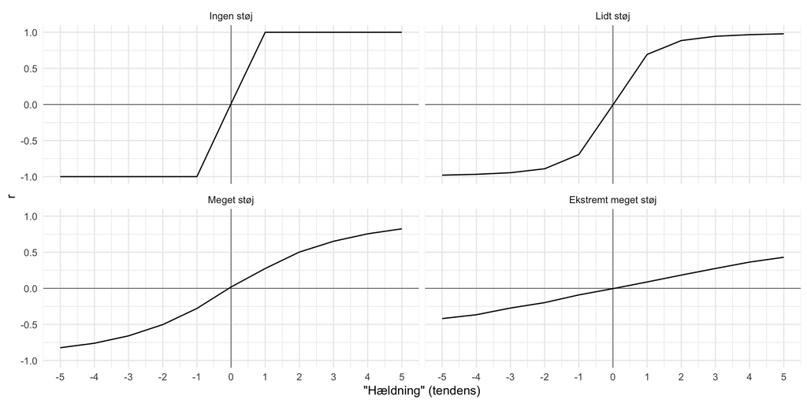

```r
set.seed(1)
vars <- crossmap::xmap(list(x = -5:5, y = c(0,3,10,30)),
               .f = ~tibble(tendens = .x,
                            støj = factor(.y))) |>
  bind_rows()

cors <- crossmap::xmap(list(x = -5:5, y = c(0,3,10,30)),
               .f = ~tibble(x = runif(n = 10000, 0, 10),
       y = x * .x + rnorm(10000, sd = .y + .00000000000000001)) |> cor()) |>
  map(2) |>
  flatten_dbl()

vars |>
  mutate(r = cors) |>
  ggplot() +
  aes(x = tendens, y = r) +
  geom_hline(yintercept = 0, linewidth = .2) +
  geom_vline(xintercept = 0, linewidth = .2) +
  geom_line() +
  facet_wrap(~ factor(støj, labels = c("Ingen støj", "Lidt støj", "Meget støj", "Ekstremt meget støj"))) +
  scale_x_continuous(breaks = -5:5) +
  theme_minimal() +
  labs(x = "\"Hældning\" (tendens)")
```

## Er korrelationer intuitive? Nej, ikke voldsomt

**Kode**

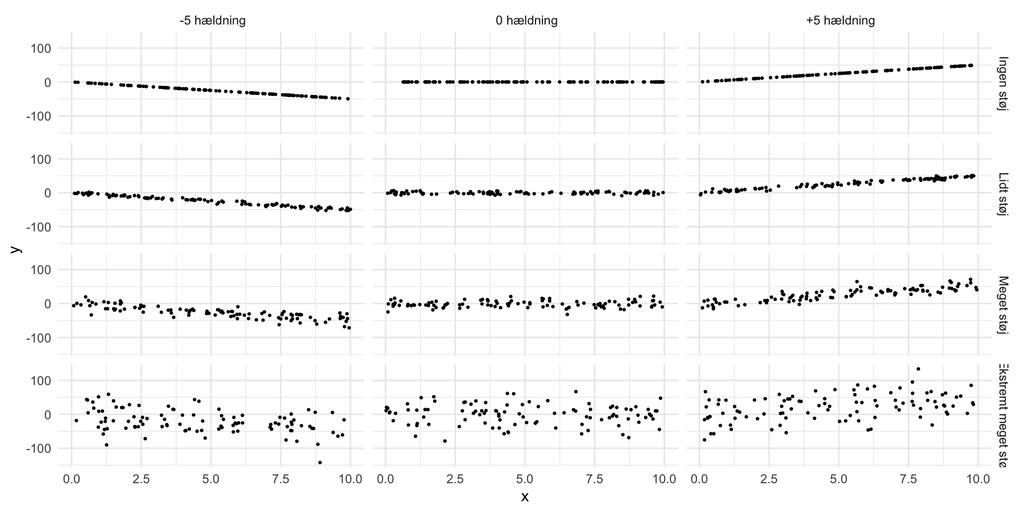

```r
set.seed(1)

crossmap::xmap(list(x = c(-5,0,5), y = c(0,3,10,30)),
               .f = ~tibble(x = runif(n = 100, 0, 10),
                            y = x * .x + rnorm(100, sd = .y + .00000000000000001))) |>
  bind_rows(.id = "id") |>
  mutate(id = factor(as.double(id), labels = c("Ingen støj: -5 hældning",
                                   "Ingen støj: 0 hældning",
                                   "Ingen støj: +5 hældning",
                                   "Lidt støj: -5 hældning",
                                   "Lidt støj: 0 hældning",
                                   "Lidt støj: +5 hældning",
                                   "Meget støj: -5 hældning",
                                   "Meget støj: 0 hældning",
                                   "Meget støj: +5 hældning",
                                   "Ekstremt meget støj: -5 hældning",
                                   "Ekstremt meget støj: 0 hældning",
                                   "Ekstremt meget støj: +5 hældning"))) |>
  separate(id, sep = ":", into = c("støj", "hældning")) |>
  mutate(støj = factor(støj, levels = c("Ingen støj", "Lidt støj", "Meget støj", "Ekstremt meget støj")),
         hældning = factor(hældning, levels = c(" -5 hældning", " 0 hældning", " +5 hældning"))) |>
  ggplot() +
  aes(x = x, y = y) +
  geom_jitter(size = .5, position = position_jitter(width = .01, height = .01)) +
  scale_y_continuous(breaks = seq(-100, 100, 100)) +
  theme_minimal() +
  facet_grid(støj ~ hældning)
```

## Pearsons *r* — advarsel

- Husk at Pearsons r estimerer den *lineære* sammenhæng
- Det kan være **farligt!**
  - 1. hvis der er en stærk, men **ikke-lineær sammenhæng**
  - 2. hvis der er markante **outliers** (værdier på begge variable skiller sig ud)

## Fare A: ikke-lineær sammenhæng

**Kode**

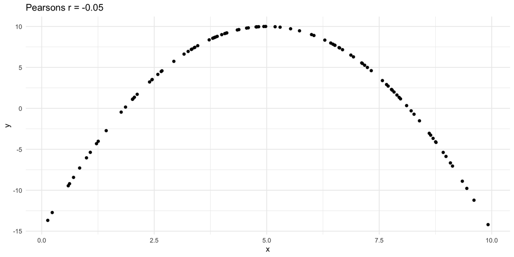

```r
set.seed(1)
dat <- tibble(x = runif(n = 100, 0, 10),
       y = -1 * (x - 5)^2 + 10)

dat |>
  ggplot() +
  aes(x = x, y = y) +
  geom_point() +
  theme_minimal() +
  labs(title = paste0("Pearsons r = ", format(round(cor(dat)[1,2], 2), nsmall = 2)))
```

## Fare B: outliers

**Kode**

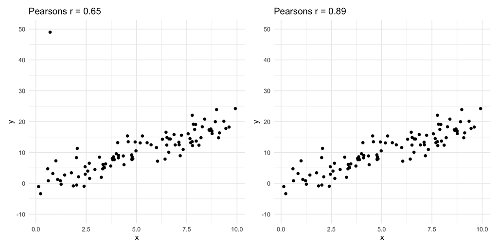

```r
set.seed(1)
dat <- tibble(x = runif(n = 100, 0, 10),
       y = x * 2 + rnorm(100, sd = 3)) |>
  arrange(x)

dat[5,2] <- 49

p1 <- dat |>
  ggplot() +
  aes(x = x, y = y) +
  geom_point() +
  theme_minimal() +
  labs(title = paste0("Pearsons r = ", format(round(cor(dat)[1,2], 2), nsmall = 2))) +
  scale_y_continuous(breaks = seq(-10,50, 10), limits = c(-10, 50))

dat2 <- dat |>
  filter(y < 49)

p2 <- dat2 |>
  ggplot() +
  aes(x = x, y = y) +
  geom_point() +
  theme_minimal() +
  labs(title = paste0("Pearsons r = ", format(round(cor(dat2)[1,2], 2), nsmall = 2))) +
  scale_y_continuous(breaks = seq(-10,50, 10), limits = c(-10, 50))

library(patchwork)
p1 + p2
```

# Eksempel på korrelationsanalyse i R (V-Dem)

## Eksempel på korrelationsanalyse i R (V-Dem)

- V-Dem datasæt med 200 lande
- Tre variable:
  - deliberation (v2dlengage): “*When important policy changes are being considered, how wide and how independent are public deliberations?*”
  - undertrykkelse (v2csreprss): “*Does the government attempt to repress civil society organizations (CSOs)?*”
  - journalister (v2meharjrn): “*Are individual journalists harassed — i.e., threatened with libel, arrested, imprisoned, beaten, or killed — by governmental or powerful nongovernmental actors while engaged in legitimate journalistic activities?*”
- Måling:
  - intervalskalerede skalaer fra *mindst* til *mest* demokratisk
  - kun nyeste målinger

**Kode**

```r
vdem <- read_csv(here::here("Data/V-Dem-CY-Core-v15_csv/V-Dem-CY-Core-v15.csv")) |>
  select(-contains("_code"), -contains("_sd")) |>
  group_by(country_name) |>
  arrange(year) |>
  slice(max(row_number())) |>
  ungroup()

vdem_select <- vdem |>
  select(country_name,
         deliberation = v2dlengage,
         undertrykkelse = v2csreprss,
         journalister = v2meharjrn) |>
  # kun lande med observationer på alle tre variable
  drop_na()

bind_rows(
  tidystats::describe_data(vdem_select, deliberation),
  tidystats::describe_data(vdem_select, undertrykkelse),
  tidystats::describe_data(vdem_select, journalister)
) |>
  knitr::kable()
```

| var | missing | N | M | SD | SE | min | max | range | median | mode | skew | kurtosis |
| --- | --- | --- | --- | --- | --- | --- | --- | --- | --- | --- | --- | --- |
| deliberation | 0 | 200 | 0.577875 | 1.277456 | 0.0903298 | -2.809 | 3.819 | 6.628 | 0.6115 | 1.819 | -0.1986534 | 2.592471 |
| undertrykkelse | 0 | 200 | 0.506095 | 1.607657 | 0.1136785 | -3.136 | 3.085 | 6.221 | 0.6910 | 1.823 | -0.2848676 | 2.036133 |
| journalister | 0 | 200 | 0.317660 | 1.425853 | 0.1008230 | -2.998 | 3.719 | 6.717 | 0.4385 | 1.152 | -0.0663078 | 2.495536 |

## Eksempel på korrelationsanalyse i R (V-Dem)

**Kode**

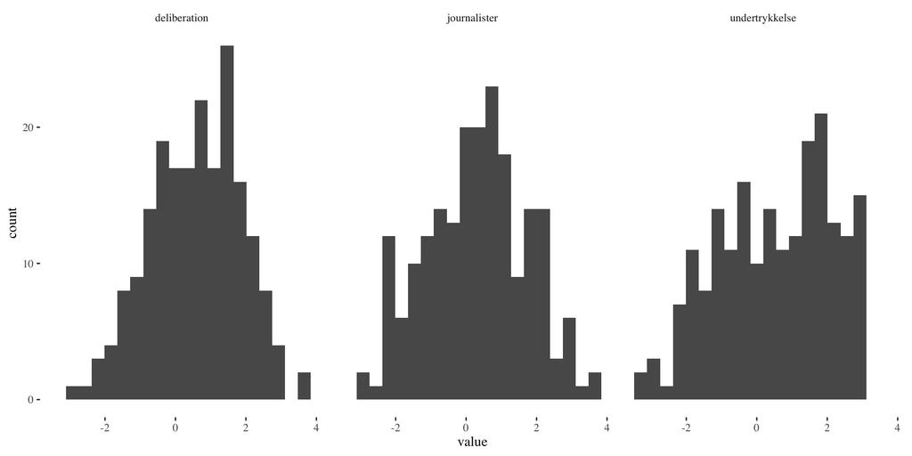

```r
vdem_select |>
  pivot_longer(c(deliberation, undertrykkelse, journalister), names_to = "indicator") |>
  ggplot() +
  aes(x = value) +
  geom_histogram(bins = 20) +
  facet_wrap(~ indicator) +
  ggthemes::theme_tufte()
```

## Eksempel på korrelationsanalyse i R (V-Dem)

**Kode**

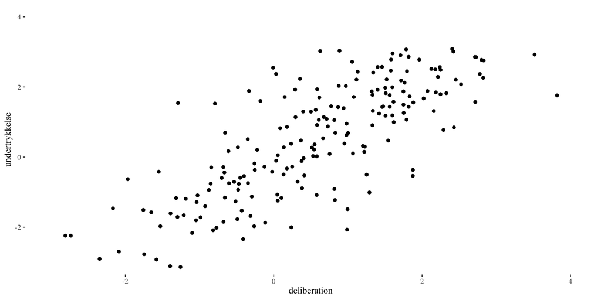

```r
vdem_select |>
  ggplot() +
  aes(x = deliberation, undertrykkelse) +
  geom_point() +
  ggthemes::theme_tufte() +
  coord_cartesian(xlim = c(-3, 4), ylim = c(-3, 4))
```

## Eksempel på korrelationsanalyse i R (V-Dem)

**Kode**

```r
# variansen af X (deliberation)
var(vdem_select$deliberation,
    use = "complete")
```

```
[1] 1.631895
```

**Kode**

```r
# variansen af Y (undertrykkelse)
var(vdem_select$undertrykkelse,
    use = "complete")
```

```
[1] 2.584562
```

**Kode**

```r
# samvariansen af X og Y (ikke til at fortolke, bortset fra *retning*/fortegn)
cov(vdem_select$deliberation,
    vdem_select$undertrykkelse,
    use = "complete")
```

```
[1] 1.583887
```

## Eksempel på korrelationsanalyse i R (V-Dem)

```r
# korrelationen (Pearsons r) mellem X og Y
cor(vdem_select$deliberation,
    vdem_select$undertrykkelse,
    use = "complete")
```

```
[1] 0.7712314
```

- Positiv/negativ sammenhæng?
- Stærk korrelation?
- Pearsons *r* = kovariansen `cov()` af *standardiserede variable*
- `scale(y)[,1]` standardiserer en variabel
  - dvs. fratrækker gennemsnittet og dividerer med standardafvigelsen (z-værdier)

**Kode**

```r
cov(scale(vdem_select$deliberation)[,1],
    scale(vdem_select$undertrykkelse)[,1],
    use = "complete")
```

```
[1] 0.7712314
```

## Hvad med journalister og deliberation?

**Kode**

```r
# korrelationen (Pearsons r) mellem X/Y, X/Z, Y/Z
vdem_select |>
  select(-country_name) |>
  cor(use = "pairwise") |> # "pairwise" smider færrest muligt væk ved flere variable
  as_tibble(rownames = "var") |>
  kableExtra::kable(digits = 2)
```

| var | deliberation | undertrykkelse | journalister |
| --- | --- | --- | --- |
| deliberation | 1.00 | 0.77 | 0.81 |
| undertrykkelse | 0.77 | 1.00 | 0.84 |
| journalister | 0.81 | 0.84 | 1.00 |

## Hvad med Spearmans rho?

**Kode**

```r
# korrelationen (Spearmans rho) mellem X/Y, X/Z, Y/Z
vdem_select |>
  select(-country_name) |>
  cor(use = "pairwise", method = "spearman") |> # spearman
  as_tibble(rownames = "var") |>
  kableExtra::kable(digits = 2)
```

| var | deliberation | undertrykkelse | journalister |
| --- | --- | --- | --- |
| deliberation | 1.00 | 0.76 | 0.79 |
| undertrykkelse | 0.76 | 1.00 | 0.86 |
| journalister | 0.79 | 0.86 | 1.00 |

## Spearmans rho = Pearsons r af *ranken*

**Kode**

```r
c(1, 5, 4, 200, 201, 999) |> # rå værdier
  rank() # ranks
```

```
[1] 1 3 2 4 5 6
```

**Kode**

```r
# pearsons r af ranks
vdem_select |>
  select(-country_name) |>
  mutate(across(everything(), rank)) |> # ranks
  cor(use = "pairwise", method = "pearson") |>
  as_tibble(rownames = "var") |>
  kableExtra::kable(digits = 2)
```

| var | deliberation | undertrykkelse | journalister |
| --- | --- | --- | --- |
| deliberation | 1.00 | 0.76 | 0.79 |
| undertrykkelse | 0.76 | 1.00 | 0.86 |
| journalister | 0.79 | 0.86 | 1.00 |

## Er korrelationerne statistisk signifikante?

- Hvad er sandsynligheden for, at en tilfældig stikprøve
  - trukket fra den relevante stikprøvemålsfordeling
  - med 200 enheder
  - ville give dette – eller et mere ekstremt – korrelationsestimat
  - hvis den sande korrelation var = 0?
  - **→ p-værdien**
  - under den konventionelle grænse på 0.05?
- Afhænger af størrelsen på (a) stikprøven og (b) koefficienten
  - a lidt lille?
  - b ret stor?
- Metode: `cor.test(x,y)`
  - samme syntaks som `cor()` (sådan ca., virker kun med *to variable*)

## Er korrelationerne statistisk signifikante?

**Kode**

```r
# signifikanstest for korrelation (Pearsons r) mellem deliberation og undertrykkelse
cor.test(vdem_select$deliberation,
         vdem_select$undertrykkelse,
         use = "complete")
```

```
    Pearson's product-moment correlation

data:  vdem_select$deliberation and vdem_select$undertrykkelse
t = 17.048, df = 198, p-value < 0.00000000000000022
alternative hypothesis: true correlation is not equal to 0
95 percent confidence interval:
 0.7082770 0.8220156
sample estimates:
      cor
0.7712314
```

- Samme korrelationskoefficient som før
- Statistisk signifikant?
- `cor.test()` giver også et *konfidensinterval*

# Lad os teste vores intuition

→ https://correlation.streamlit.app/

## Til nørderne: oversættelse mellem kovariation, korrelation og regressionskoefficient (1)

```r
# variable
x <- vdem_select$deliberation
y <- vdem_select$undertrykkelse

# varians og standardafvigelser
(xvar <- var(x))
## [1] 1.631895
(yvar <- var(y))
## [1] 2.584562
(xsd <- sd(x))
## [1] 1.277456
(ysd <- sd(y))
## [1] 1.607657

# m: bivariat regresionsmodel
(m <- lm(y ~ x))
##
## Call:
## lm(formula = y ~ x)
##
## Coefficients:
## (Intercept)            x
##    -0.05478      0.97058

# c: regressionskoefficient for x
(c <- coef(m)["x"])
##         x
## 0.9705817

# c: regressionskoefficient for x
(r2 <- summary(m)$r.squared)
## [1] 0.5947978

# r: pearsons r
(r <- cor(x, y))
## [1] 0.7712314

# cvar: kovarians
(cvar <- cov(x, y))
## [1] 1.583887
```

## Til nørderne: oversættelse mellem kovariation, korrelation og regressionskoefficient (2)

```r
# regressionskoefficient -> Pearsons r
(c * xsd / ysd)
##         x
## 0.7712314
r
## [1] 0.7712314

# pearsons r -> regressionskoefficient
(r * ysd / xsd)
## [1] 0.9705817
c
##         x
## 0.9705817

# regressionskoefficient -> covariance
(c * xvar)
##        x
## 1.583887
cvar
## [1] 1.583887

# covariance -> regressionskoefficient
(cvar / xvar)
## [1] 0.9705817
c
##         x
## 0.9705817

# pearsons r -> covariance
(r * ysd * xsd)
## [1] 1.583887
cvar
## [1] 1.583887

# covariance -> pearsons r
(cvar / (ysd * xsd))
## [1] 0.7712314
r
## [1] 0.7712314

# pearsons r -> R-squared (R^2)
r^2
## [1] 0.5947978
r2
## [1] 0.5947978

# R-squared (R^2) -> (positiv) pearsons r
sqrt(r2)
## [1] 0.7712314
r
## [1] 0.7712314
```

# Lineær regressionsanalyse

# Men først: Betingede gennemsnit

## Betingede gennemsnit

- “**Gennemsnittet**” → ja ja, enhver variabel har et samlet gennemsnit
  - men der kan være forskellige gennemsnit, hvis vi tager højde for en *anden variabel*
  - → *betingede gennemsnit* af Y afhængigt af værdien af X
- Hvorfor interessant?
  - dels en form for bivariat (sammenhængs)analyse, jf. forrige uger
  - men også **essensen i lineær regression**
- Lineær regression udregner i princippet **betingede gennemsnit** *betinget af værdien på de(n) uafhængige variable*
- Den kan også udregne **lige linjer**:
  - minder om en stribe betingede gennemsnit
  - tvunget til at have en bestemt form
  - bedste lineære **‘fit’** → bedste beskrivelse af datapunkterne med en ret linje

## Betingede gennemsnit

**Kode**

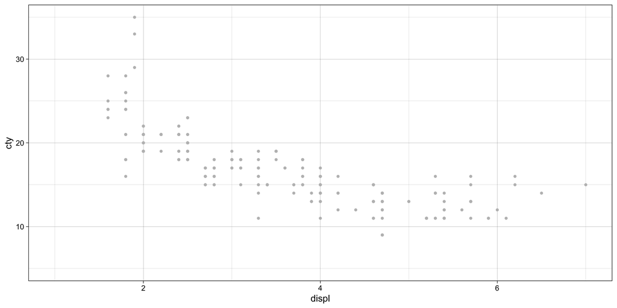

```r
# base plot (x = displ, y = cty)
p0 <- mpg |>
  ggplot() +
  aes(x = displ, y = cty) +
  coord_cartesian(xlim = c(1, 7), ylim = c(5, 35)) +
  theme_linedraw() +
  geom_point(size = 1, color = "grey")

# base plot med facets
p1 <- p0 +
  facet_wrap(~ n_grupper, nrow = 2)

# 1-8 betingede gennemsnit
bgns <- map(1:8, ~mpg |>
            mutate(displ_kat = cut_number(displ, .)) |>
            group_by(displ_kat) |>
            summarise(displ = mean(displ),
                      cty = mean(cty),
                      n = n()) |>
            ungroup()) |>
  bind_rows(.id = "n_grupper") |>
  mutate(n_grupper = as.integer(n_grupper))

# vis base plot
p0
```

## 1 betinget gennemsnit

```r
p1 + geom_point(size = 2.5, color = "red3", data = filter(bgns, n_grupper == 1))
```

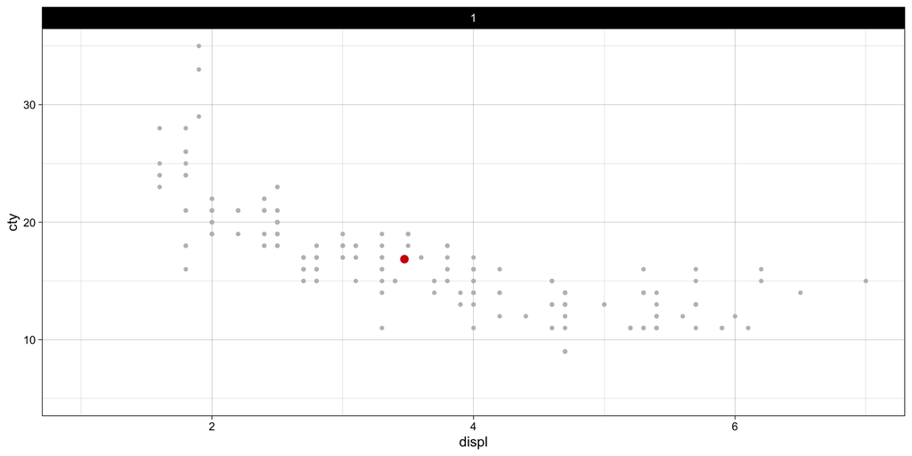

## 2 betingede gennemsnit

```r
p1 + geom_point(size = 2.5, color = "red3", data = filter(bgns, n_grupper == 2)) # 2 lige store grupper
```

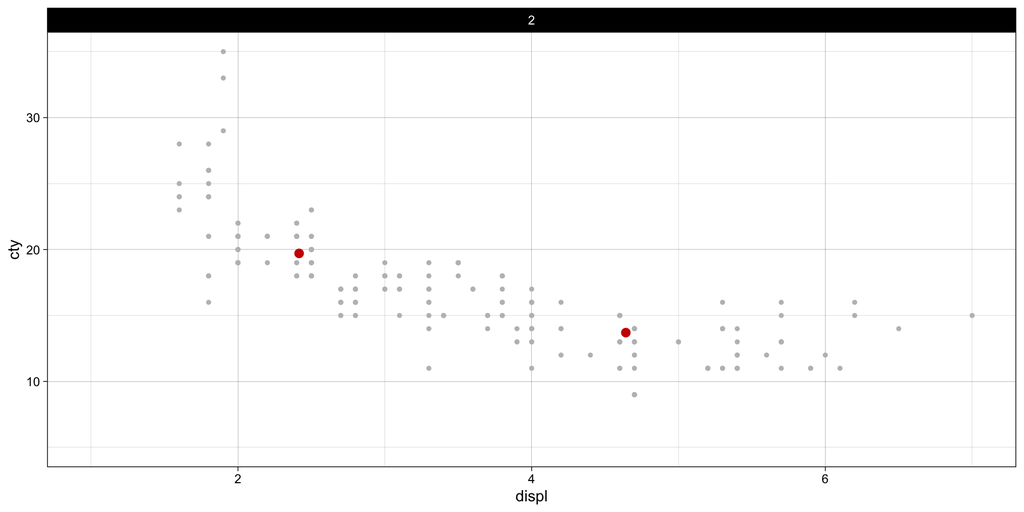

## 3 betingede gennemsnit

```r
p1 + geom_point(size = 2.5, color = "red3", data = filter(bgns, n_grupper == 3)) # 3 lige store grupper
```

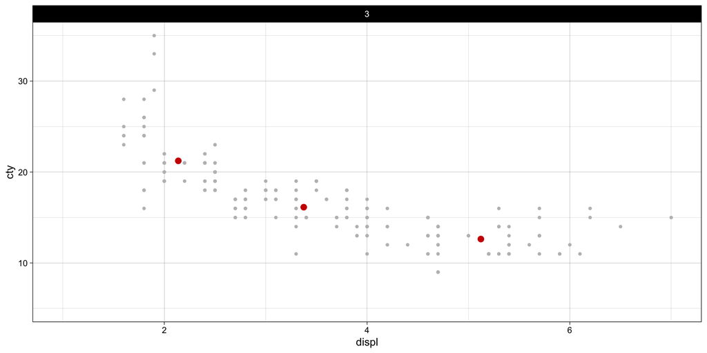

## 4 betingede gennemsnit

```r
p1 + geom_point(size = 2.5, color = "red3", data = filter(bgns, n_grupper == 4)) # 4 lige store grupper
```

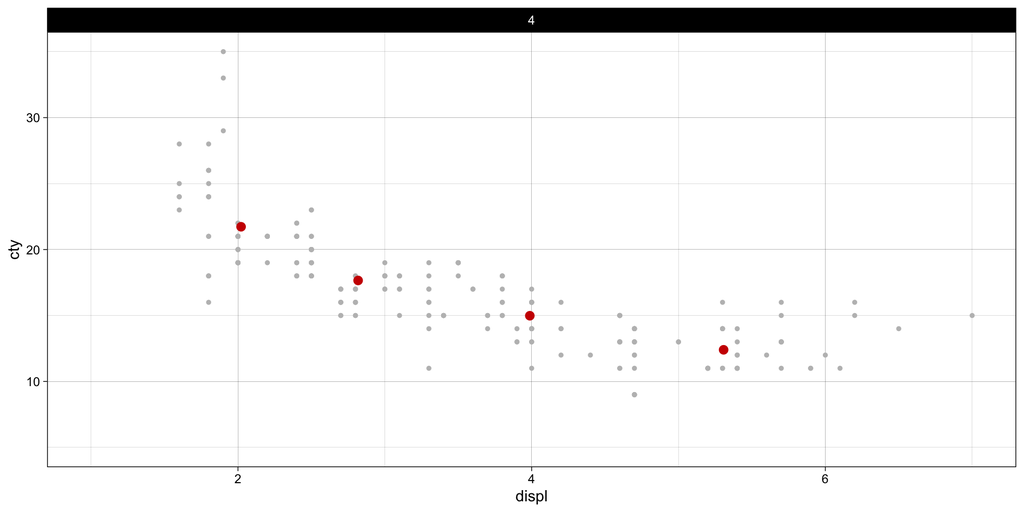

## 5 betingede gennemsnit

```r
p1 + geom_point(size = 2.5, color = "red3", data = filter(bgns, n_grupper == 5)) # 5 lige store grupper
```

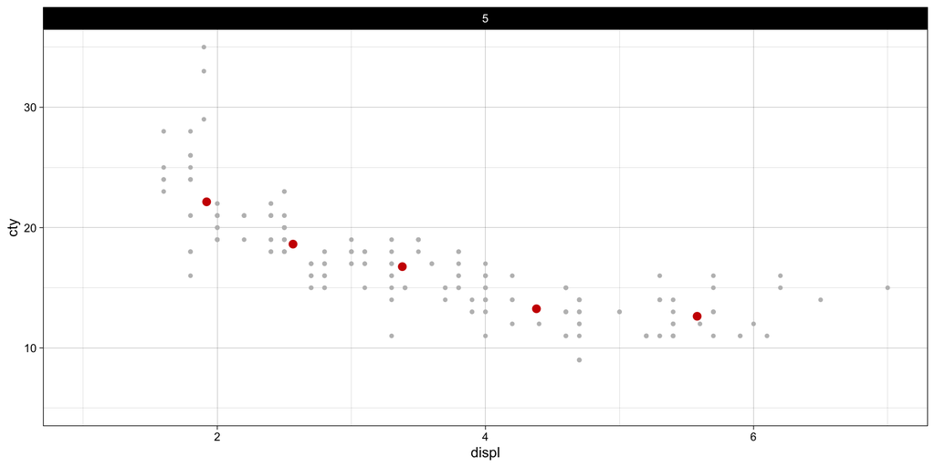

## Mange betingede gennemsnit

```r
p1 +
  geom_point(size = 2.5, color = "red3", data = bgns)
```

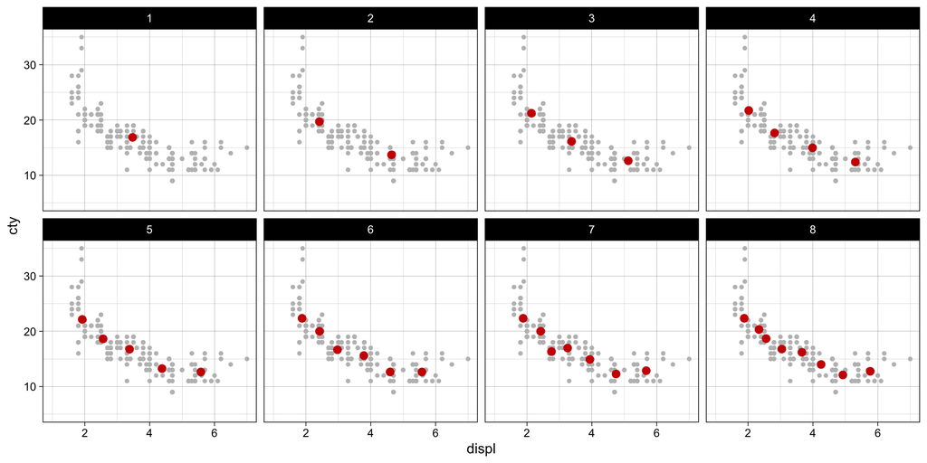

## Mange betingede gennemsnit

```r
p1 + geom_smooth(method = "loess", data = mpg, se = FALSE, color = "blue3") + # "loess": lokale gns.
  geom_point(size = 2.5, color = "red3", data = bgns)
```

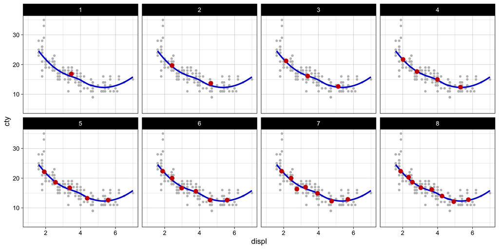

## En enkelt *ret linje*

```r
p1 + geom_smooth(method = "lm", data = mpg, se = FALSE, color = "blue3") + # "lm": lineær model
  geom_point(size = 2.5, color = "red3", data = bgns)
```

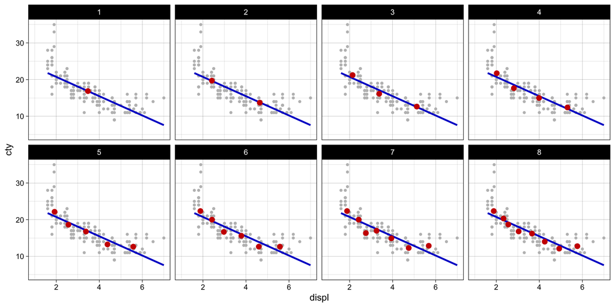

# Tilbage til: Lineær regressionsanalyse

## Lineær regressionsanalyse

- Vi ‘*regresser*’ en afhængig variabel, Y (kun 1!), på en eller flere uafhængige variable, X
- **Formål:**
  - v1: at forklare variansen i Y ud fra variansen i X
  - v2: at beskrive hvordan gennemsnittet af Y ændrer sig med niveauet af X
  - v3: at forudsige Y på baggrund af vores viden om X
  - v4: at estimere hvor meget ændringer i værdien af X påvirker værdien af Y
- Metoden kaldes også **OLS**:
  - ordinary least squares
  - mindste kvadraters metode
  - henviser til måden, hvorpå metoden vælger de *“bedste”* rette linjer
- I R: `lm(Y ~ X, data = data)`

## Regressionsanalyse i R – intervalskaleret X

**Kode**

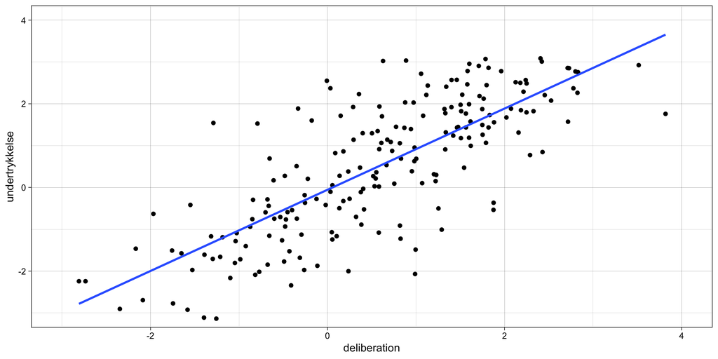

```r
vdem_select |>
  ggplot() +
  aes(x = deliberation, undertrykkelse) +
  geom_point() +
  geom_smooth(method = "lm", se = FALSE) + # lineær linje
  theme_linedraw() +
  coord_cartesian(xlim = c(-3, 4), ylim = c(-3, 4))
```

## Regressionsanalyse i R – intervalskaleret X

**Kode**

```r
# OLS-regressionskoefficienter
lm(undertrykkelse ~ deliberation, data = vdem_select) |>
  summary()
```

```
Call:
lm(formula = undertrykkelse ~ deliberation, data = vdem_select)

Residuals:
     Min       1Q   Median       3Q      Max
-2.97413 -0.49625 -0.04753  0.58575  2.84883

Coefficients:
             Estimate Std. Error t value            Pr(>|t|)
(Intercept)  -0.05478    0.07966  -0.688               0.492
deliberation  0.97058    0.05693  17.048 <0.0000000000000002 ***
---
Signif. codes:  0 '***' 0.001 '**' 0.01 '*' 0.05 '.' 0.1 ' ' 1

Residual standard error: 1.026 on 198 degrees of freedom
Multiple R-squared:  0.5948,    Adjusted R-squared:  0.5928
F-statistic: 290.6 on 1 and 198 DF,  p-value: < 0.00000000000000022
```

## Regressionsanalyse i R – binær/kategorisk X

**Kode**

```r
vdem_select2 <- vdem |>
  transmute(country_name,
            histname,
            # binær
            navn_democratic = if_else(str_detect(tolower(histname), "democratic"), 1, 0, 0), # er der "democratic" i navnet (ja/nej)?
            # kategorisk
            navn_type = case_when(str_detect(tolower(histname), "republic") ~ "republic", # er der "republic" i navnet?
                                  str_detect(tolower(histname), "kingdom") ~ "kingdom", # er der "kingdom" i navnet?
                                  .default = "andet"), # ellers -> "andet"
            deliberation = v2dlengage,
            undertrykkelse = v2csreprss,
            journalister = v2meharjrn) |>
  # kun lande med observationer på alle tre variable
  drop_na()
```

## Regressionsanalyse i R – binær X

**Kode**

```r
vdem_select2 |>
  group_by(navn_democratic) |>
  summarise(n = n(),
            eksempler = paste(sample(histname, 3), collapse = ", "),
            undertrykkelse = round(mean(undertrykkelse), 3)) |>
  kable() |>
  kable_styling(font_size = 32)
```

| navn_democratic | n | eksempler | undertrykkelse |
| --- | --- | --- | --- |
| 0 | 186 | Gaza Strip under Hamas control, Ireland [independence recognized], Canada | 0.559 |
| 1 | 11 | People's Democratic Republic of Yemen, Democratic Republic of Timor-Leste [independent state], Federal Democratic Republic of Nepal | 0.075 |

## Regressionsanalyse i R – binær X

**Kode**

```r
lm(undertrykkelse ~ navn_democratic, data = vdem_select2) |>
  summary()
```

```
Call:
lm(formula = undertrykkelse ~ navn_democratic, data = vdem_select2)

Residuals:
    Min      1Q  Median      3Q     Max
-3.6951 -1.2621  0.2629  1.3139  2.6425

Coefficients:
                Estimate Std. Error t value   Pr(>|t|)
(Intercept)       0.5591     0.1174   4.763 0.00000372 ***
navn_democratic  -0.4836     0.4968  -0.974      0.331
---
Signif. codes:  0 '***' 0.001 '**' 0.01 '*' 0.05 '.' 0.1 ' ' 1

Residual standard error: 1.601 on 195 degrees of freedom
Multiple R-squared:  0.004837,  Adjusted R-squared:  -0.0002666
F-statistic: 0.9478 on 1 and 195 DF,  p-value: 0.3315
```

## Regressionsanalyse i R – simpelt gennemsnit

**Kode**

```r
# gennemsnit
mean(vdem_select$undertrykkelse)
```

```
[1] 0.506095
```

**Kode**

```r
# univariat lineær regression -> konstant (Intercept)
lm(undertrykkelse ~ 1, data = vdem_select) |>
  summary()
```

```
Call:
lm(formula = undertrykkelse ~ 1, data = vdem_select)

Residuals:
    Min      1Q  Median      3Q     Max
-3.6421 -1.2558  0.1849  1.3227  2.5789

Coefficients:
            Estimate Std. Error t value  Pr(>|t|)
(Intercept)   0.5061     0.1137   4.452 0.0000142 ***
---
Signif. codes:  0 '***' 0.001 '**' 0.01 '*' 0.05 '.' 0.1 ' ' 1

Residual standard error: 1.608 on 199 degrees of freedom
```

## Regressionsanalyse i R – kategorisk X

**Kode**

```r
vdem_select2 |>
  group_by(navn_type) |>
  summarise(n = n(),
            undertrykkelse = round(mean(undertrykkelse), 3)) |>
  kable() |>
  kable_styling(font_size = 32)
```

| navn_type | n | undertrykkelse |
| --- | --- | --- |
| andet | 49 | 0.389 |
| kingdom | 20 | 0.418 |
| republic | 128 | 0.604 |

## Regressionsanalyse i R – kategorisk X

**Kode**

```r
lm(undertrykkelse ~ navn_type, data = vdem_select2) |>
  summary()
```

```
Call:
lm(formula = undertrykkelse ~ navn_type, data = vdem_select2)

Residuals:
    Min      1Q  Median      3Q     Max
-3.7404 -1.3074  0.2176  1.3146  2.6806

Coefficients:
                  Estimate Std. Error t value Pr(>|t|)
(Intercept)        0.38941    0.22940   1.697   0.0912 .
navn_typekingdom   0.02894    0.42610   0.068   0.9459
navn_typerepublic  0.21503    0.26976   0.797   0.4264
---
Signif. codes:  0 '***' 0.001 '**' 0.01 '*' 0.05 '.' 0.1 ' ' 1

Residual standard error: 1.606 on 194 degrees of freedom
Multiple R-squared:  0.003836,  Adjusted R-squared:  -0.006434
F-statistic: 0.3735 on 2 and 194 DF,  p-value: 0.6888
```

## Regressionsanalyse i R – opsummering

- Regressionsmodellen laver *betingede gennemsnit* (kategoriske/binære X) eller *rette linjer* (intervalskaleret X)
  - for at forklare/forudsige alle enhedernes værdi af Y bedst pba. kendskab til X
- Vi er primært interesseret i **regressionskoefficienterne** (også kaldet *beta*-koef., $\beta$):
  - *hvor meget højere/lavere er Y, når X vokser med +1* (intervalskaleret)
  - *hvor meget højere/lavere er Y, når X = 1 sammenlignet med X = 0* (binær)
  - *hvor meget højere/lavere er Y, når X = b, c eller d sammenlignet med referencekategorien a* (kategorisk)
- Dernæst i resultatet af den indbyggede **signifikanstest**
  - koefficienternes *p-værdier*
  - hvor usandsynlig er sammenhængen, hvis den i virkeligheden er 0?
- Derefter i *konstanten*, *R^2*, *forudsagte værdier af Y*, *residualerne*, mv.

## “Styrken” af en bivariat sammenhæng

- Lad os sammenligne Pearsons r og OLS-regressionskoefficienter
- Vi varierer:
  - 1. hældningen/størrelsen på sammenhængen mellem X og Y
  - 2. spredningen af Y (støj)
  - 3. de absolutte værdier af Y

## “Styrken” af en bivariat sammenhæng

> Vi varierer kun styrken/hældningen i sammenhængen mellem X og Y → begge varierer

**Kode**

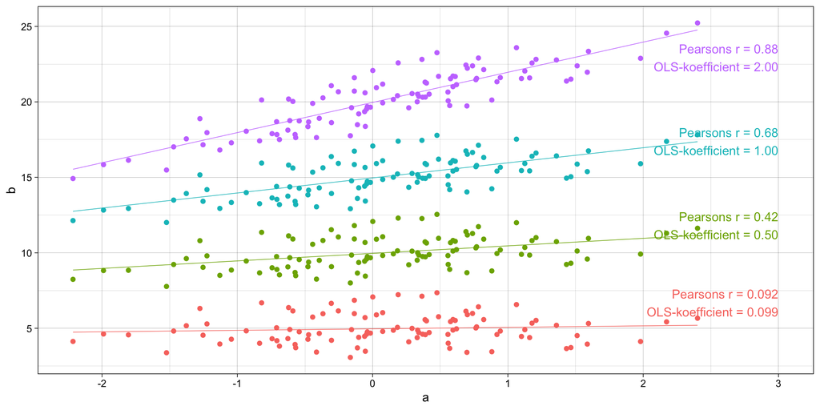

```r
set.seed(1)
df <- tibble(a = rnorm(100),
             b_noise = rnorm(100),
             b1 = 5 + a * .1 + b_noise,
             b2 = 10 + a * .5 + b_noise,
             b3 = 15 + a * 1 + b_noise,
             b4 = 20 + a * 2 + b_noise,
) |>
  pivot_longer(c(b1, b2, b3, b4), names_to = "v", values_to = "b")

df_calc <- df |>
  group_by(v) |>
  mutate(r = format(cor(a, b), digits = 2, nsmall = 2),
         c = format(pluck(coef(lm(b ~ a)), 2), digits = 2, nsmall = 2)) |>
  ungroup() |>
  group_by(v, r, c) |>
  summarise(a = 3,
            b = quantile(b, probs = .95))

df |>
  ggplot() +
  aes(x = a, y = b, color = v) +
  geom_point() +
  geom_smooth(method = "lm", se = FALSE, linewidth = .25) +
  geom_text(aes(label = paste0("Pearsons r = ", r, "\n", "OLS-koefficient = ", c)), hjust = 1, data = df_calc) +
  theme_linedraw() +
  guides(color = "none")
```

## “Styrken” af en bivariat sammenhæng

> Vi varierer kun spredningen af Y (tilfældig støj) → kun *r* varierer

**Kode**

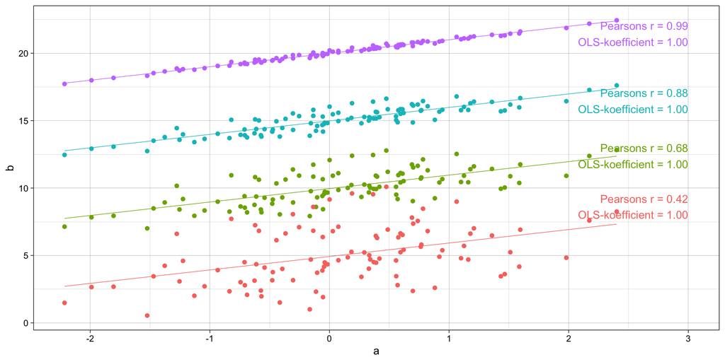

```r
set.seed(1)
df <- tibble(a = rnorm(100),
             b_noise = rnorm(100),
             b1 = 5 + a * 1 + b_noise * 2,
             b2 = 10 + a * 1 + b_noise * 1,
             b3 = 15 + a * 1 + b_noise * .5,
             b4 = 20 + a * 1 + b_noise * .1,
) |>
  pivot_longer(c(b1, b2, b3, b4), names_to = "v", values_to = "b")

df_calc <- df |>
  group_by(v) |>
  mutate(r = format(cor(a, b), digits = 2, nsmall = 2),
         c = format(pluck(coef(lm(b ~ a)), 2), digits = 2, nsmall = 2)) |>
  ungroup() |>
  group_by(v, r, c) |>
  summarise(a = 3,
            b = quantile(b, probs = .95))

df |>
  ggplot() +
  aes(x = a, y = b, color = v) +
  geom_point() +
  geom_smooth(method = "lm", se = FALSE, linewidth = .25) +
  geom_text(aes(label = paste0("Pearsons r = ", r, "\n", "OLS-koefficient = ", c)), hjust = 1, data = df_calc) +
  theme_linedraw() +
  guides(color = "none")
```

## “Styrken” af en bivariat sammenhæng

> Vi varierer kun Y-skalaen (‘blæser Y op’) → kun OLS-koefficienten varierer

**Kode**

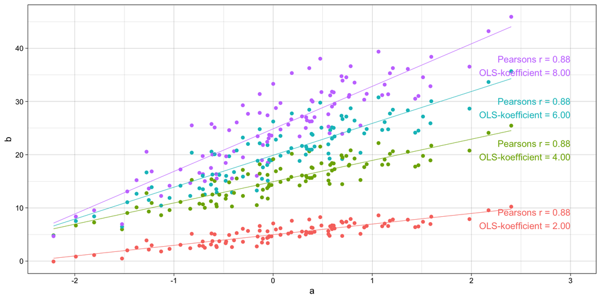

```r
set.seed(1)
df <- tibble(a = rnorm(100),
             b1 = 5 + a * 2 + rnorm(100),
             b2 = 5 + b1 * 2,
             b3 = 5 + b1 * 3,
             b4 = 5 + b1 * 4,
) |>
  pivot_longer(c(b1, b2, b3, b4), names_to = "v", values_to = "b")

df_calc <- df |>
  group_by(v) |>
  mutate(r = format(cor(a, b), digits = 2, nsmall = 2),
         c = format(pluck(coef(lm(b ~ a)), 2), digits = 2, nsmall = 2)) |>
  ungroup() |>
  group_by(v, r, c) |>
  summarise(a = 3,
            b = quantile(b, probs = .95))

df |>
  ggplot() +
  aes(x = a, y = b, color = v) +
  geom_point() +
  geom_smooth(method = "lm", se = FALSE, linewidth = .25) +
  geom_text(aes(label = paste0("Pearsons r = ", r, "\n", "OLS-koefficient = ", c)), hjust = 1, data = df_calc) +
  theme_linedraw() +
  guides(color = "none")
```

## Pearsons r og R^2 (OLS)

- Enhver OLS-model estimerer modellens såkaldte $R^2$:
  - hvor stor andel af variansen i Y kan modellens X’er forklare?
    - gang med 100 → %
  - mao. hvor meget/lidt uforklaret varians er der tilbage?

```r
# regressionsmodel med intervalskaleret X
m <- lm(undertrykkelse ~ deliberation, data = vdem_select2) |>
  summary()

# kun modellensR^2
m$r.squared
```

```
[1] 0.6004754
```

```r
# Pearsons r
cor(vdem_select2$undertrykkelse, vdem_select2$deliberation)
```

```
[1] 0.7749035
```

```r
# Pearsons r ^ 2 (i anden)
cor(vdem_select2$undertrykkelse, vdem_select2$deliberation) ^ 2
```

```
[1] 0.6004754
```

## Hvorfor hedder det *Ordinary Least Squares*?

**Kode**

```r
m <- lm(cty ~ displ, data = mpg)
mpg$pred <- predict(m)
mpg$resid <- resid(m)

p_ols1 <- p0 +
  geom_smooth(method = "lm", se = FALSE, color = "red3")

p_ols1 + labs(title = "Datapunkter og 'bedste' lige linje")
```

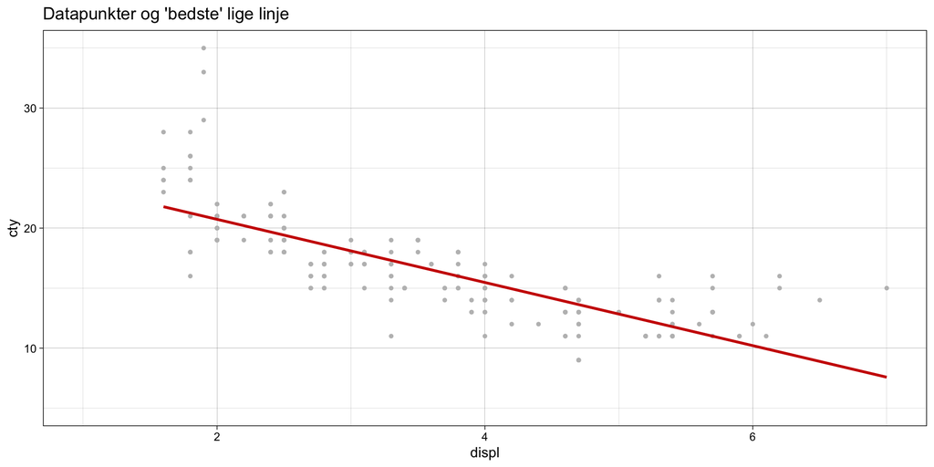

## Hvorfor hedder det *Ordinary Least Squares*?

**Kode**

```r
p_ols1 +
  geom_linerange(aes(xmin = displ, xmax = displ, ymin = pred, ymax = cty), alpha = .25, linewidth = 1, data = filter(mpg, resid > 0)) +
  geom_linerange(aes(xmin = displ, xmax = displ, ymin = cty, ymax = pred), alpha = .25, linewidth = 1, data = filter(mpg, resid < 0)) +
  geom_smooth(method = "lm", se = FALSE, color = "red3") +
  labs(title = "Residualer (uforklaret varians)")
```

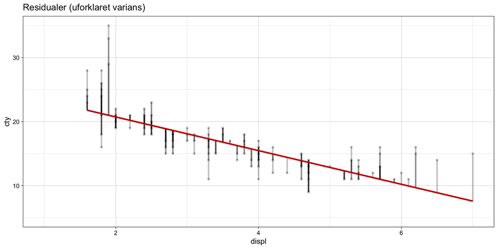

## Hvorfor hedder det *Ordinary Least Squares*?

**Kode**

```r
p_ols1 +
  geom_linerange(aes(xmin = displ, xmax = displ, ymin = pred, ymax = cty), alpha = .25, linewidth = 1, data = filter(mpg, resid > 0)) +
  geom_linerange(aes(xmin = displ, xmax = displ, ymin = cty, ymax = pred), alpha = .25, linewidth = 1, data = filter(mpg, resid < 0)) +
  geom_rect(aes(xmin = displ + resid, xmax = displ, ymin = pred, ymax = cty), alpha = .025, linewidth = .1, color = "black", data = mpg) + geom_smooth(method = "lm", se = FALSE, color = "red3", data = mpg)   +
  labs(title = "Kvadrerede residualer (uens skalaer)")
```

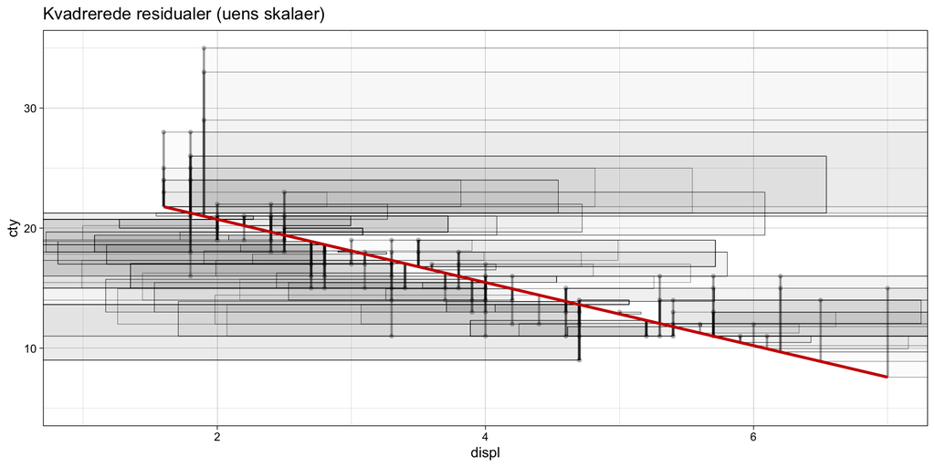

## Hvorfor hedder det *Ordinary Least Squares*?

**Kode**

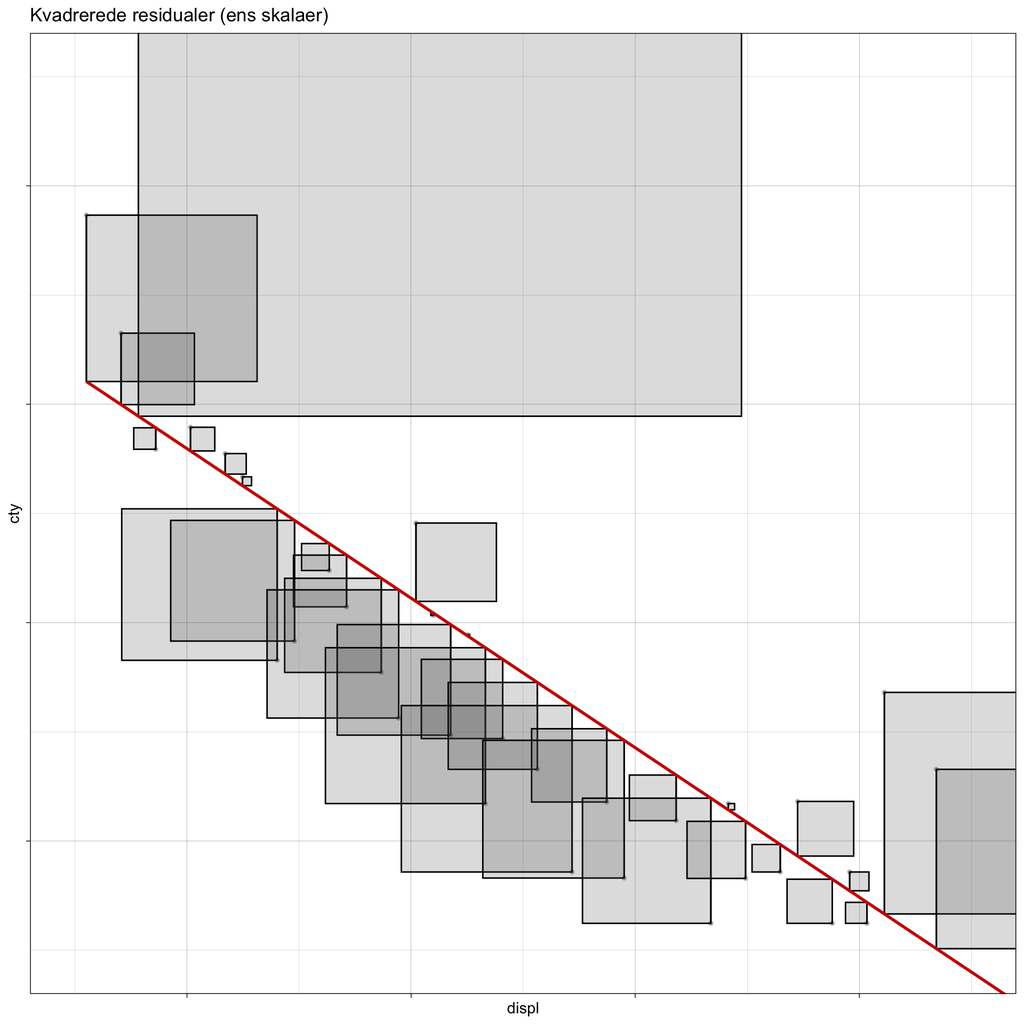

```r
mpg_simpel <- mpg |>
  mutate(displ = scale(displ)[,1],
         cty = scale(cty)[,1]) |>
  group_by(displ) |>
  summarise(displ = mean(displ),
            cty = mean(cty)) |>
  ungroup()

m <- lm(cty ~ displ, data = mpg_simpel)
mpg_simpel$pred <- predict(m)
mpg_simpel$resid <- resid(m)

mpg_simpel |>
  ggplot() +
  aes(x = displ, y = cty) +
  theme_linedraw() +
  geom_point(size = 1, color = "grey") +
  geom_linerange(aes(xmin = displ, xmax = displ, ymin = pred, ymax = cty), linewidth = .5, data = filter(mpg_simpel, resid > 0)) +
  geom_linerange(aes(xmin = displ, xmax = displ, ymin = cty, ymax = pred), linewidth = .5, data = filter(mpg_simpel, resid < 0)) +
  geom_rect(aes(xmin = displ + resid, xmax = displ, ymin = pred, ymax = cty), alpha = .2, linewidth = .5, color = "black") +
  geom_smooth(method = "lm", se = FALSE, color = "red3") +
  coord_cartesian(xlim = c(-1.5, 2.5), ylim = c(-1.5,2.5)) +
  theme(axis.text = element_blank()) +
  labs(title = "Kvadrerede residualer (ens skalaer)")
```

## Multivariat regression

- Det geniale twist er, at man kan have mange uafhængige variable med i sin regressionsmodel på samme tid!
- *Multivariat* lineær regression (3+ variable)
  - samme logik: vi vil beskrive vores data så enkelt som muligt
  - → nu partielle sammenhænge mellem Y/X1, Y/X2 etc.
  - ultimativt er lineær regression stadig en slags avanceret gennemsnitsmaskine
  - en generel/avanceret måde at beskrive data!
- OLS-modellen *fitter* bedste linjer (eller planer) for alle variable på samme tid

## Multivariat regression

- Regressionskoefficienterne viser de partielle sammenhænge mellem Y og hvert enkelt X
  - uafhængigt af de andre X
  - partielle bivariate korrelationer
  - justeret for korrelation med de andre variable
  - mao. skyldes en del af korrelationen, at X og Y begge korrelerer med Z?
- Skulle man visualisere det, ville det kræve mange dimensioner (eller mange figurer)
  - men metoden minimerer stadig bare alle kvadraterne og fortæller os om resultatet
- Vi vender tilbage til **multivariat regression** samt relationenen til **kausalitet** næste gang

## Opsummering

- *Pearsons r* er nærmest synonymt med bivariat *korrelation*
  - kvantificerer sammenhængen (samvariationen) mellem to intervalskalerede variable
  - `cor(x, y, use = "...")`
  - standardiseret fra -1 til +1
  - ikke altid intuitivt, bl.a. fordi den afspejler både støj/varians og hældning/tendens
  - nært beslægtet med andre sammenhængsmål (kovarians, Spearmans rho)
- **Lineær regression** (OLS) er genialt!
  - anvendes til at estimere, hvordan/hvor meget et Y afhænger af et/flere X
  - `lm(y ~ x, data = data)`
  - intuitivt (omend avanceret), ekstremt fleksibelt og alsidigt:
    - *(betingede) gennemsnit, partielle sammenhænge, univariat, bivariat, multivariat, intervalskalerede/kategoriske/binære variable, forudsigelse, kausaleffekter osv. osv.*

## Næste uge

- Meget mere OLS!
- Nok den vigtigste primær-metode i kvantitativ samfundsvidenskab